# Midterm_Koob_Elise_2018

#### Second, see if a very small sample size (n = 10) would at least include 0.4 in it’s 95% Credible Interval.

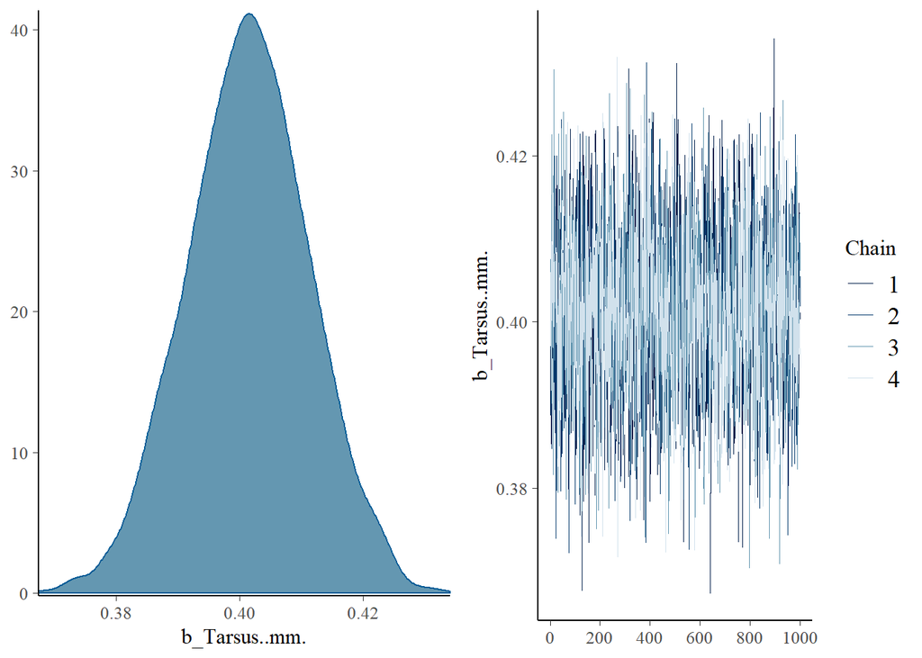

```r
#random sample of quail (n = 10)
quail_sub <- sample_n(quail, 10)

#rerun bayes model
quail_bayes_sub <- brm(Culmen..mm. ~ Tarsus..mm.,
                           family = gaussian(link = "identity"),
                           data = quail_sub,
                           prior = prior(normal(0.4, 0.01), class = b),
                           file = "quail_bayes_sub.Rds")

#this time slope is centered around the prior value of 0.4; this shows that the data did not overwhelm the prior this time

plot(quail_bayes_sub, par = "b_Tarsus..mm.")
```

```r
#min-max = 0.367-0.434
quail_bayes_sub_posterior <- posterior_samples(quail_bayes_sub,
                                    add_chain = TRUE)
min(quail_bayes_sub_posterior$b_Tarsus..mm.)
```

```
## [1] 0.3674245
```

```r
max(quail_bayes_sub_posterior$b_Tarsus..mm.)
```

```
## [1] 0.4340761
```

```r
#0.4 included in CI's
posterior_summary(quail_bayes_sub)
```

```
##                  Estimate   Est.Error        Q2.5      Q97.5
## b_Intercept    -0.7051820 0.478479531  -1.6463425  0.2305615
## b_Tarsus..mm.   0.4014051 0.009845793   0.3821612  0.4207629
## sigma           0.9045069 0.350034525   0.4838202  1.7287231
## lp__          -11.2852360 1.320210809 -14.6481289 -9.7754826
```

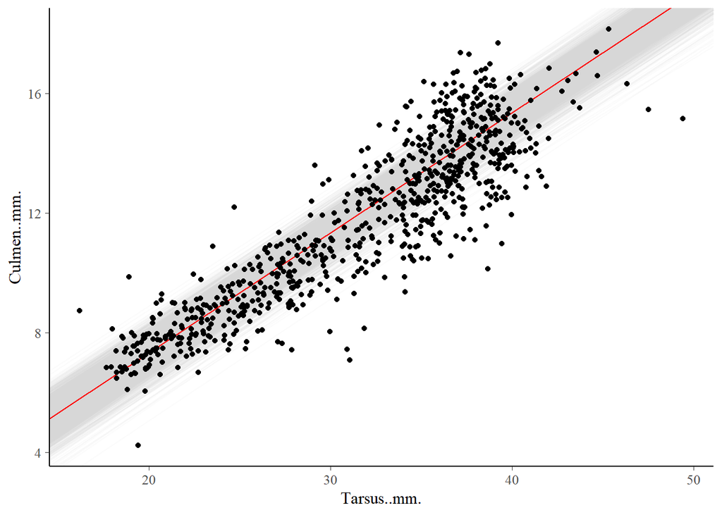

```r
#visualize model [CI of fit MUCH wider]
quail_chains_sub <- as.data.frame(quail_bayes_sub)

quail_plot +
  geom_abline(intercept=quail_chains_sub[,1], slope = quail_chains_sub[,2], alpha=0.1, color="lightgrey") +
  geom_abline(intercept=fixef(quail_bayes_sub)[1], slope = fixef(quail_bayes_sub)[2], color="red") +
  geom_point()
```

#### Last, demonstrate at what sample size that 95% CL first begins to include 0.4 when we have a strong prior. How much data do we really need to overcome our prior belief? Note, it takes a long time to fit these models, so, try a strategy of spacing out the 3-4 sample sizes, and then zoom in on an interesting region.

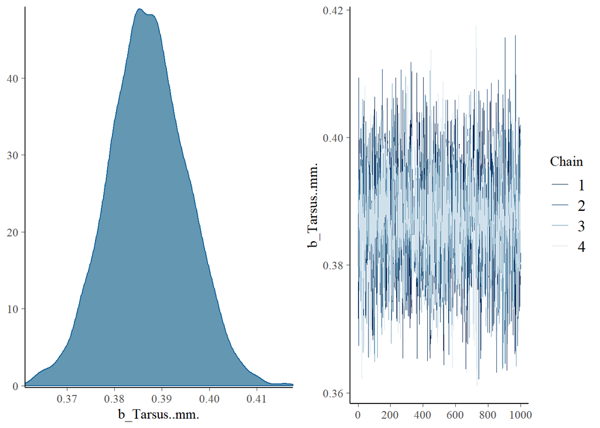

```r
#sample size of 10 with prior = 0.4; INCLUDES 0.4
#sample size of 766 with prior = 0.4; DOES NOT include 0.4
#what sample size do we start to see 0.4 included?

#random sample of quail (n = 200)
quail_sub_200 <- sample_n(quail, 200)

#rerun bayes model
quail_bayes_sub_200 <- brm(Culmen..mm. ~ Tarsus..mm.,
                           family = gaussian(link = "identity"),
                           data = quail_sub_200,
                           prior = prior(normal(0.4, 0.01), class = b),
                           file = "quail_bayes_sub_200.Rds")

##includes 0.40
plot(quail_bayes_sub_200, par = "b_Tarsus..mm.")
```

```r
posterior_summary(quail_bayes_sub_200)
```

```
##                   Estimate   Est.Error         Q2.5         Q97.5
## b_Intercept     -0.5895482 0.275877733   -1.1280068   -0.04278596
## b_Tarsus..mm.    0.3870398 0.008272182    0.3709719    0.40315775
## sigma            1.2979628 0.071183205    1.1681944    1.44405356
## lp__          -298.1633217 1.240132501 -301.3658227 -296.73169235
```

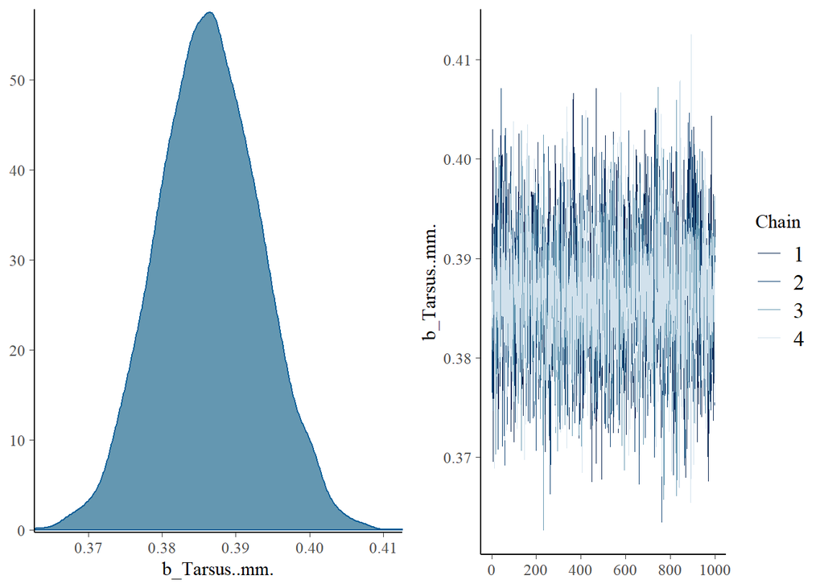

```r
#random sample of quail (n = 400)
quail_sub_400 <- sample_n(quail, 400)

#rerun bayes model
quail_bayes_sub_400 <- brm(Culmen..mm. ~ Tarsus..mm.,
                           family = gaussian(link = "identity"),
                           data = quail_sub_400,
                           prior = prior(normal(0.4, 0.01), class = b),
                           file = "quail_bayes_sub_400.Rds")

##includes 0.40, but barely
plot(quail_bayes_sub_400, par = "b_Tarsus..mm.")
```

```r
posterior_summary(quail_bayes_sub_400)
```

```
##                   Estimate   Est.Error         Q2.5         Q97.5
## b_Intercept     -0.5270730 0.226218245   -0.9677288   -0.08813666
## b_Tarsus..mm.    0.3863831 0.006910366    0.3731676    0.40017679
## sigma            1.2273225 0.046847628    1.1400048    1.32168981
## lp__          -571.9642264 1.228083989 -575.1000018 -570.57041543
```

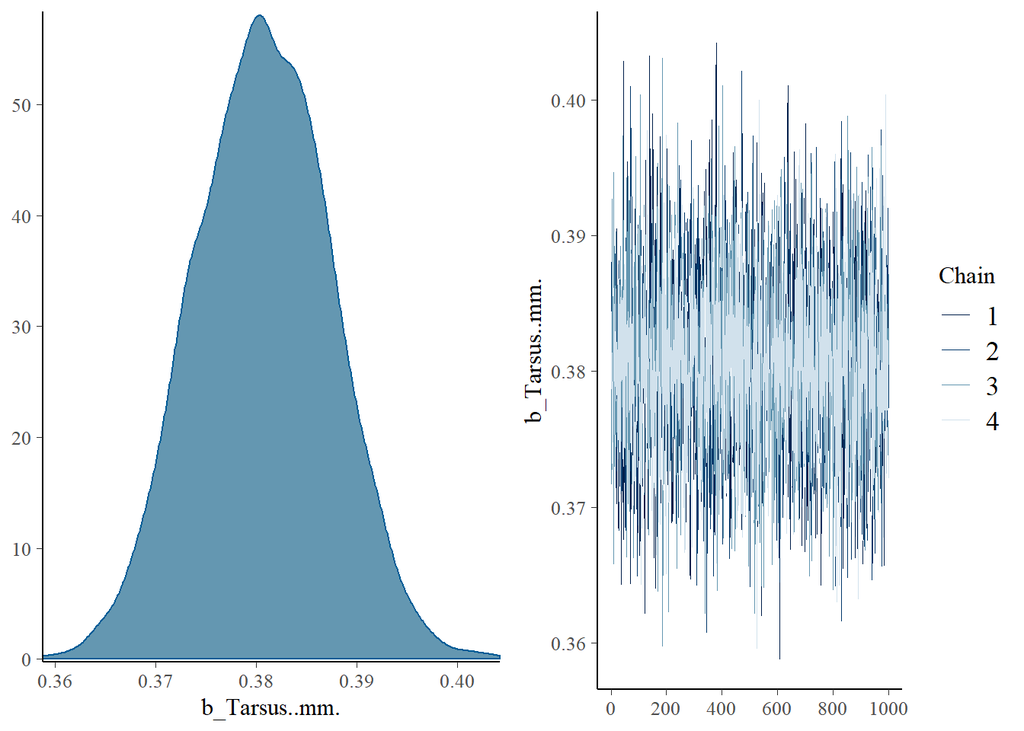

```r
#random sample of quail (n = 500)
quail_sub_500 <- sample_n(quail, 500)

#rerun bayes model
quail_bayes_sub_500 <- brm(Culmen..mm. ~ Tarsus..mm.,
                           family = gaussian(link = "identity"),
                           data = quail_sub_500,
                           prior = prior(normal(0.4, 0.01), class = b),
                           file = "quail_bayes_sub_500.Rds")

##0.4 NOT included in CI
plot(quail_bayes_sub_500, par = "b_Tarsus..mm.")
```

```r
posterior_summary(quail_bayes_sub_500)
```

```
##                   Estimate   Est.Error         Q2.5         Q97.5
## b_Intercept     -0.3655006 0.220235494   -0.7828236    0.05941389
## b_Tarsus..mm.    0.3807221 0.006667648    0.3679377    0.39357480
## sigma            1.2595510 0.043697379    1.1786024    1.34819872
## lp__          -726.3410897 1.204079756 -729.5134070 -724.95583392
```

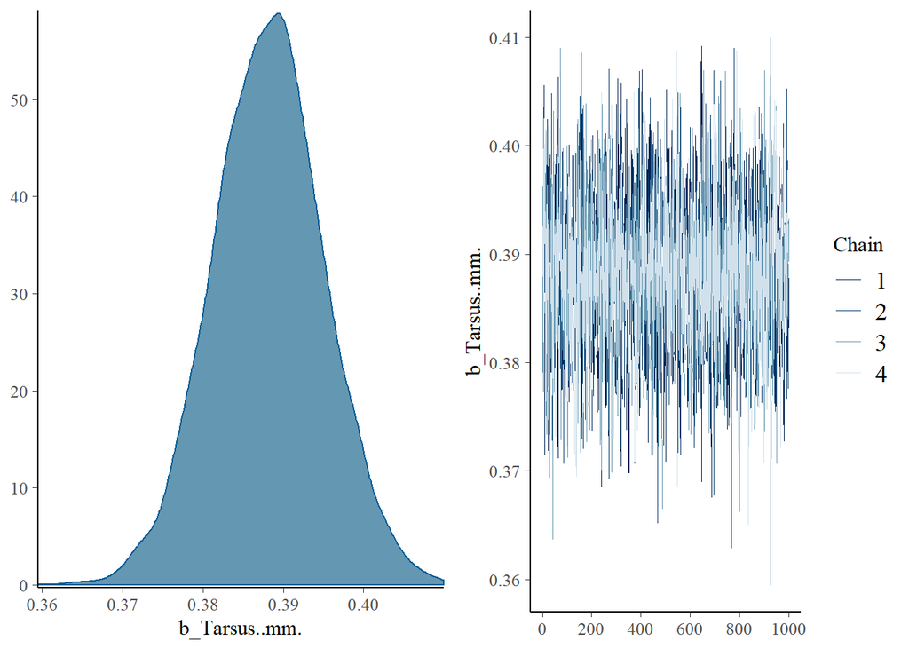

```r
#random sample of quail (n = 450)
quail_sub_450 <- sample_n(quail, 450)

#rerun bayes model
quail_bayes_sub_450 <- brm(Culmen..mm. ~ Tarsus..mm.,
                           family = gaussian(link = "identity"),
                           data = quail_sub_450,
                           prior = prior(normal(0.4, 0.01), class = b),
                           file = "quail_bayes_sub_450.Rds")

##includes 0.40
plot(quail_bayes_sub_450, par = "b_Tarsus..mm.")
```

```r
posterior_summary(quail_bayes_sub_450)
```

```
##                   Estimate   Est.Error         Q2.5         Q97.5
## b_Intercept     -0.5147663 0.227167571   -0.9655915   -0.06031675
## b_Tarsus..mm.    0.3881680 0.006848307    0.3747706    0.40177824
## sigma            1.2319753 0.044408668    1.1476853    1.32258551
## lp__          -643.3943649 1.272614848 -646.7094195 -641.99999235
```

```r
#Looks like somwehere between 450 and 500 samples is where 0.40 would start to show up in CI's. Therefore, n = 500 is roughly the number of samples we would need to overwhelm the prior.
```

### 6. Extra Credit Make an election forecast

#### 1 point for the correct winner. 5 points for correctly predicting the popular vote and being within 10% (3% just for trying!). 5 points for predicting the electoral college and geting no more than 5 states wrong (3 points just for trying). 5 points for predicting the senate races getting no more than 5 states wrong (3 points just for trying). 1 extra point for each vote percentage within your 80% Confidence/Credible Interval. Ditto for the house races

Did what I could with what time I had left! From what I was able to do (if correct) it looks like the race for the house was too close to reliably call! There is a large overlap in confidence intervals.

```r
library(pollstR)
library(reshape2)

#used data from pollstR: An R Client for the HuffPost Pollster API

#house race data
slug <- "2018-national-house-race"
polls <- pollster_charts_polls(slug)[["content"]]
str(polls)
```

[output not shown]

```r
#generate weights & multiply each poll by weight
polls <- polls %>%
  as.data.frame() %>%
  mutate(pollWeights = polls$observations/sum(polls$observations, na.rm = T))

polls <- polls %>%
  mutate(DemocratWeighted = polls$Democrat * polls$pollWeights,
         RepublicanWeighted = polls$Republican * polls$pollWeights,
         OtherWeighted = polls$Other * polls$pollWeights,
         UndecidedWeighted = polls$Undecided * polls$pollWeights)

colnames(polls)
```

```
##  [1] "Democrat"             "Republican"           "Other"
##  [4] "Undecided"            "poll_slug"            "survey_house"
##  [7] "start_date"           "end_date"             "question_text"
## [10] "sample_subpopulation" "observations"         "margin_of_error"
## [13] "mode"                 "partisanship"         "partisan_affiliation"
## [16] "pollWeights"          "DemocratWeighted"     "RepublicanWeighted"
## [19] "OtherWeighted"        "UndecidedWeighted"
```

```r
#sum for weighted average
sumDems <- sum(polls$DemocratWeighted, na.rm = T)
sumReps <- sum(polls$RepublicanWeighted, na.rm = T)
sumOther <- sum(polls$OtherWeighted, na.rm = T)
sumUndec <- sum(polls$UndecidedWeighted, na.rm = T)

#make sure equals ~100
sum(sumDems, sumReps, sumOther, sumUndec)
```

```
## [1] 99.96693
```

```r
#weighted variance
Dem_Var <-  sqrt(sum(polls$pollWeights * (polls$Democrat-sumDems)^2, na.rm = T))
Rep_Var <-  sqrt(sum(polls$pollWeights * (polls$Republican-sumReps)^2, na.rm = T))
Undec_Var <-  sqrt(sum(polls$pollWeights * (polls$Undecided-sumUndec)^2, na.rm = T))
Other_Var <-  sqrt(sum(polls$pollWeights * (polls$Other-sumOther)^2, na.rm = T))

#probability density functions
polls <- polls %>%
  mutate(Dem_pdf = dnorm(polls$Democrat,sumDems, Dem_Var),
         Rep_pdf = dnorm(polls$Republican,sumReps, Rep_Var),
         Other_pdf = dnorm(polls$Other,sumOther, Other_Var),
         Undec_pdf = dnorm(polls$Undecided,sumUndec, Undec_Var))

colnames(polls)
```

```
##  [1] "Democrat"             "Republican"           "Other"
##  [4] "Undecided"            "poll_slug"            "survey_house"
##  [7] "start_date"           "end_date"             "question_text"
## [10] "sample_subpopulation" "observations"         "margin_of_error"
## [13] "mode"                 "partisanship"         "partisan_affiliation"
## [16] "pollWeights"          "DemocratWeighted"     "RepublicanWeighted"
## [19] "OtherWeighted"        "UndecidedWeighted"    "Dem_pdf"
## [22] "Rep_pdf"              "Other_pdf"            "Undec_pdf"
```

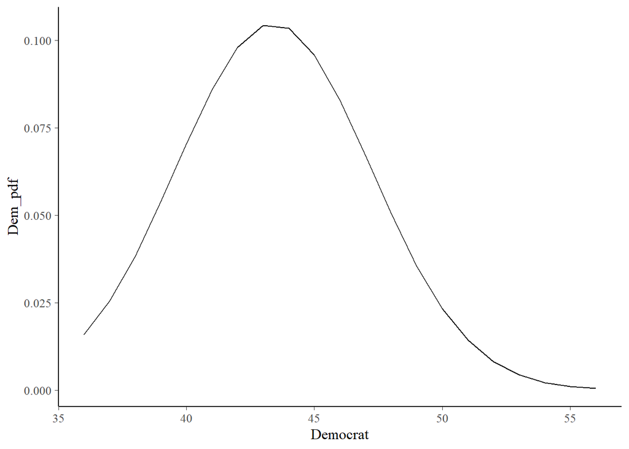

```r
#plot densities; normal
ggplot(polls, aes(x = Democrat, y = Dem_pdf)) +
  geom_line()
```

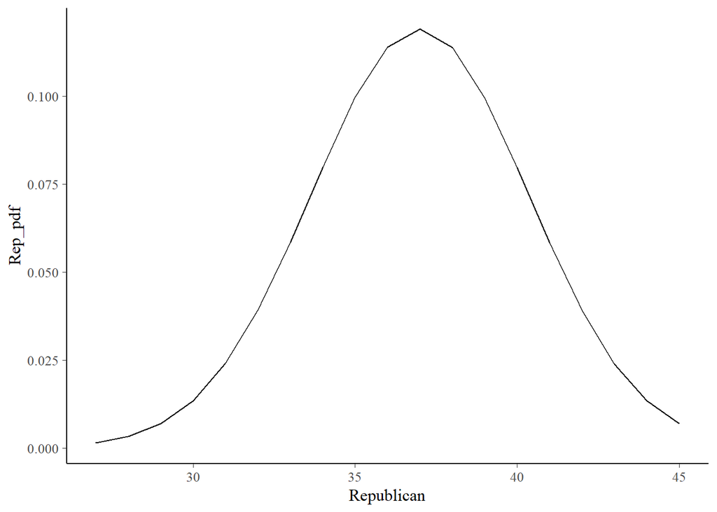

```r
#normal
ggplot(polls, aes(x = Republican, y = Rep_pdf)) +
  geom_line()
```

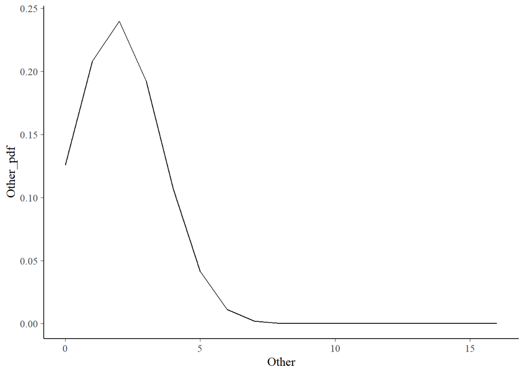

```r
#little funky (lack of data?); looks like gamma distribution
ggplot(polls, aes(x = Other, y = Other_pdf)) +
  geom_line()
```

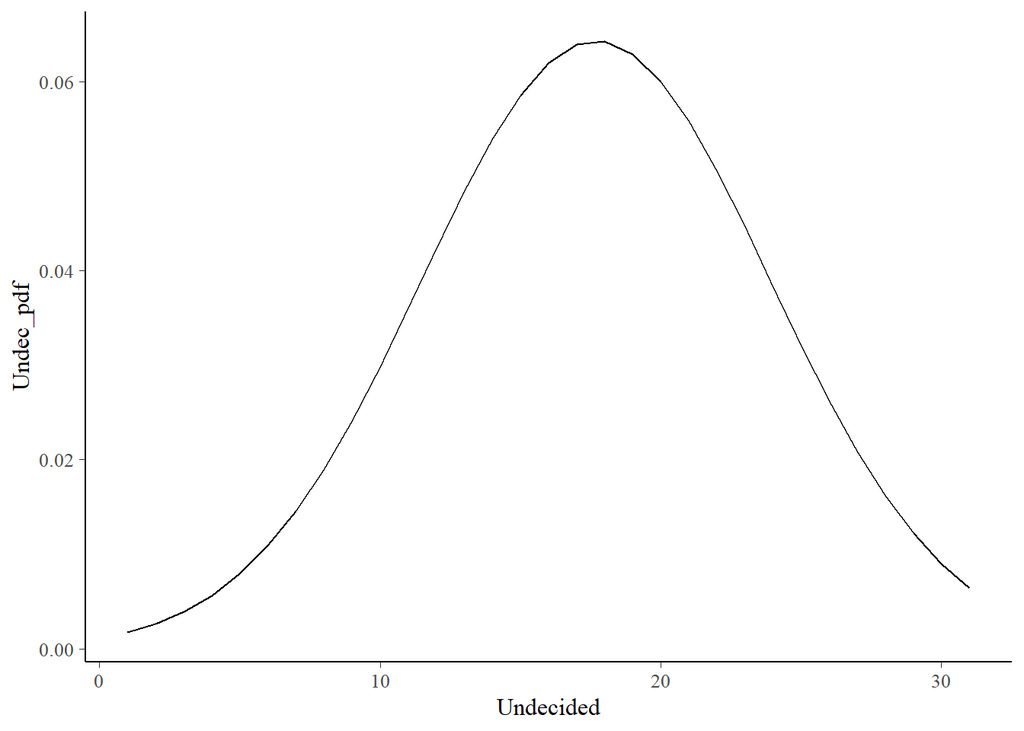

```r
#normal
ggplot(polls, aes(x = Undecided, y = Undec_pdf)) +
  geom_line()
```

```r
#CIs
#Democrats
Dem_CI_low <- sumDems - (2 * Dem_Var)
Dem_CI_high <-sumDems + (2 * Dem_Var)
Dem_CI_low; Dem_CI_high
```

```
## [1] 35.78359
```

```
## [1] 51.00729
```

```r
#Republicans
Rep_CI_low <- sumReps - (2 * Rep_Var)
Rep_CI_high <- sumReps + (2 * Rep_Var)
Rep_CI_low; Rep_CI_high
```

```
## [1] 30.29583
```

```
## [1] 43.69387
```

```r
#Democrats: 35.78359 - 51.00729
#Republicans: 30.29583  - 43.69387
#so much overlap!!!


#write.csv(polls,'polls.csv')
#having trouble manipulating dataframe into usable columns for plotting variables
#made my own spreadsheet to use for plots

polls_2 <- read.csv("polls_tweaked.csv")
head(polls_2)
```

```
##   X   end_date    Party Percent   Weighted         pdf
## 1 1  11/3/2018 Democrat      55 0.14000699 0.001003826
## 2 2  11/2/2018 Democrat      43 0.18649095 0.104257115
## 3 3  11/1/2018 Democrat      51 0.08312839 0.014240439
## 4 4 10/30/2018 Democrat      47 0.13471457 0.066937947
## 5 5 10/30/2018 Democrat      49 0.14987526 0.035445601
## 6 6 10/23/2018 Democrat      50 0.08160900 0.023255944
```

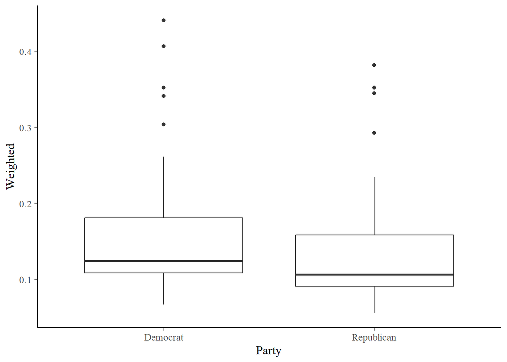

```r
#boxplots (a lot of overlap)
ggplot(polls_2, aes(x = Party, y = Weighted)) +
  geom_boxplot()
```

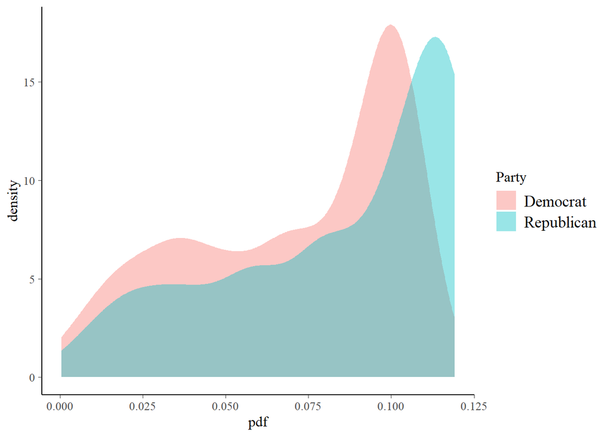

```r
#probability density function overlap
ggplot(polls_2, aes(pdf, fill=Party)) +
  geom_density(alpha=.4, color=NA)
```

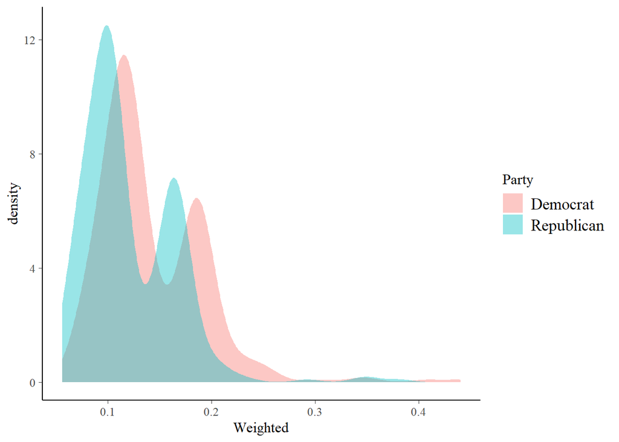

```r
#weighted polls overlap
ggplot(polls_2, aes(Weighted, fill=Party)) +
  geom_density(alpha=.4, color=NA)
```

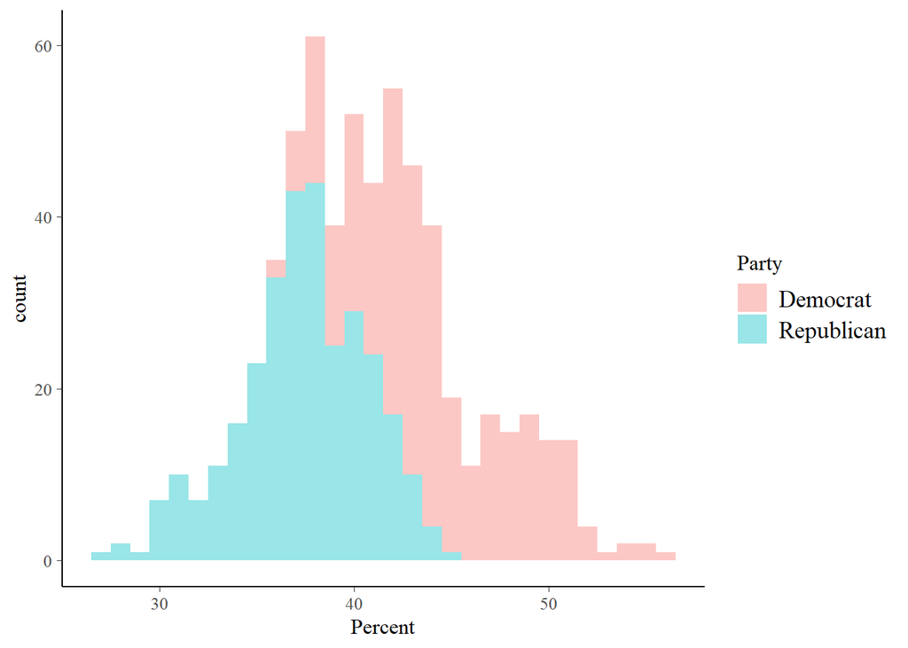

```r
#just thought these were interesting
ggplot(polls_2, aes(Percent, fill=Party)) +
  geom_histogram(alpha=.4, color=NA)
```

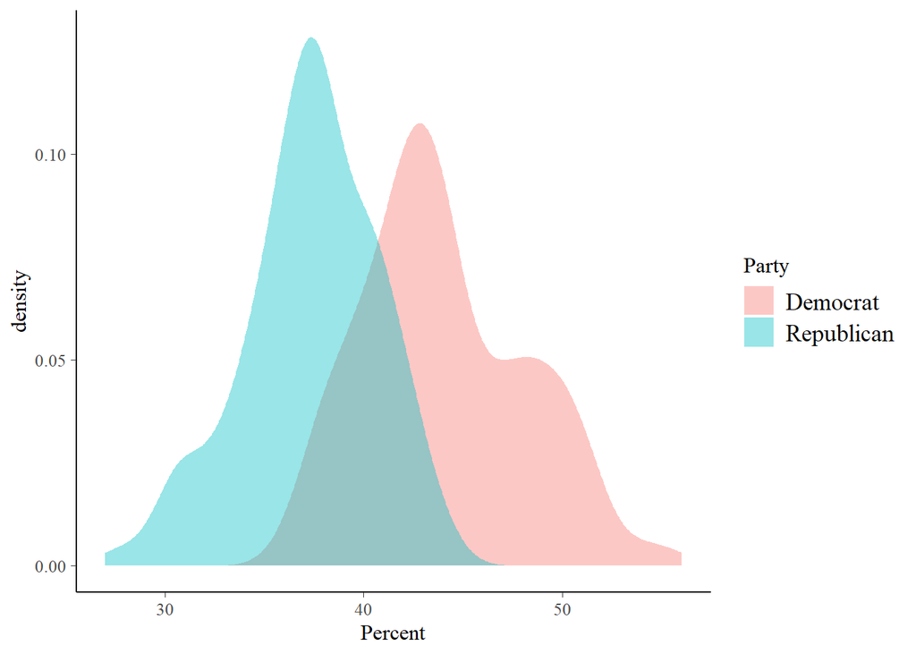

```r
ggplot(polls_2, aes(Percent, fill=Party)) +
  geom_density(alpha=.4, color=NA)
```